# Cohort_with_R

GEON SEUNG LEE

2019-12-16

## Cohort 분석이란?

코호트 분석에서 코호트(Cohort)란 **특정 기간 동안 공통된 특성이나 경험을 갖는 사용자 집단**을 의미하며,  
쉽게 표현하면 **특정 기간별 사용자 세그먼트**로 이해할 수 있습니다.

코호트 분석은 웹로그 분석 Tool인 `Google Analytics` 등에서 분석 서비스를 제공하고 있습니다.  
보통 코호트 단위로 기간 경과에 따른 **고객의 유지율과 이탈율 분석에 주로 활용**되고 있습니다.

[figure not shown]

## 예제 Dataset Load

예제에 활용될 데이터셋은 `Kaggle`의 `Retail Transaction Data`입니다.  
하기 링크에서 데이터셋에 관한 자세한 정보를 참고하세요.  
https://www.kaggle.com/regivm/retailtransactiondata

```r
library(data.table)
df_trans <- fread("Retail_Data_Transactions.csv", stringsAsFactors = FALSE)
df_respo <- fread("Retail_Data_Response.csv", stringsAsFactors = FALSE)

str(df_trans)
```

```
## Classes 'data.table' and 'data.frame':   125000 obs. of  3 variables:
##  $ customer_id: chr  "CS5295" "CS4768" "CS2122" "CS1217" ...
##  $ trans_date : chr  "11-Feb-13" "15-Mar-15" "26-Feb-13" "16-Nov-11" ...
##  $ tran_amount: int  35 39 52 99 78 81 93 89 76 75 ...
##  - attr(*, ".internal.selfref")=<externalptr>
```

```r
str(df_respo)
```

```
## Classes 'data.table' and 'data.frame':   6884 obs. of  2 variables:
##  $ customer_id: chr  "CS1112" "CS1113" "CS1114" "CS1115" ...
##  $ response   : int  0 0 1 1 1 0 1 0 0 0 ...
##  - attr(*, ".internal.selfref")=<externalptr>
```

```r
# Convert Data Type
library(lubridate)
df_trans$trans_date <- dmy(df_trans$trans_date)
```

## EDA

먼저 간단하게 데이터를 살펴보도록 하겠습니다.

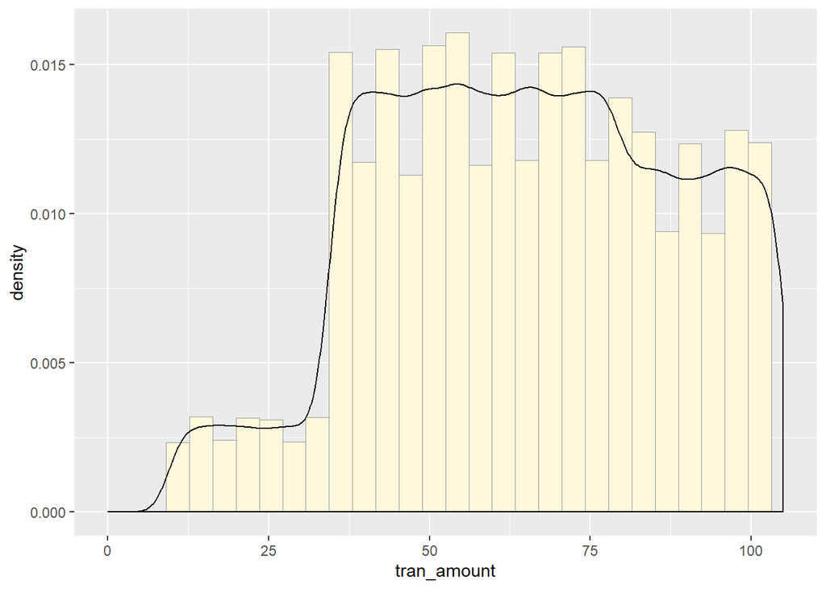

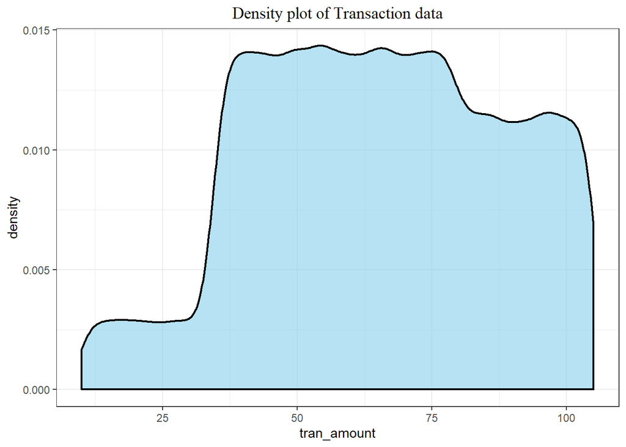

## Cohort Analysis(코호트분석)

- 코호트 분석을 위해 데이터 전처리를 진행합니다.  
  먼저 데이터셋에서 `2014년` 데이터만 `filter`합니다.

```r
library(dplyr)
cohort <- df_trans
cohort$Year <- as.numeric(format(df_trans$trans_date, '%Y'))

cohort2014 <- cohort %>%
  filter(Year == 2014) %>%
  select(customer_id, trans_date, Year) %>%
  arrange(customer_id, trans_date)
str(cohort2014)
```

```
## 'data.frame':    32226 obs. of  3 variables:
##  $ customer_id: chr  "CS1112" "CS1112" "CS1112" "CS1113" ...
##  $ trans_date : Date, format: "2014-04-29" "2014-07-16" ...
##  $ Year       : num  2014 2014 2014 2014 2014 ...
##  - attr(*, ".internal.selfref")=<externalptr>
```

- 아래의 순서에 따라서 데이터를 처리합니다.
  1. 각 고객별 첫번째 거래일자 생성 `join_date`
  2. 각 `join_date` 월별로 `Cohort` 생성하기
  3. **각 고객별로 Join data가 정확하게 생성되었는 지 확인**

```r
# Getting the first transaction dates for each customer
join.date <- aggregate(trans_date ~ customer_id, cohort2014, min, na.rm = TRUE)

# Changing the name of the column InvoiceDate to Join_Date
# since this is the first transaction date for each customer
colnames(join.date)[2] <- "Join_Date"

# Merge the Join date data to the cohort2011 data frame
cohort2014 <- merge(cohort2014, join.date, by.x = "customer_id",by.y = "customer_id", all.x = TRUE)

# Creating the groups/Cohorts based on the join date month
cohort2014$Cohort <- as.numeric(format(cohort2014$Join_Date, "%m"))

# This visualization is not necessary. We're using this
# interactive table to confirm that the join data is correct.

DT::datatable(head(cohort2014,500),
              filter = 'top',
              rownames = FALSE,
              options = list(
                pageLength = 10,
                pageLength = c(10,20,30,40,50)))
```

| customer_id | trans_date | Year | Join_Date | Cohort |
| --- | --- | --- | --- | --- |
| CS1112 | 2014-04-29 | 2014 | 2014-04-29 | 4 |
| CS1112 | 2014-07-16 | 2014 | 2014-04-29 | 4 |
| CS1112 | 2014-12-04 | 2014 | 2014-04-29 | 4 |
| CS1113 | 2014-01-07 | 2014 | 2014-01-07 | 1 |
| CS1113 | 2014-04-19 | 2014 | 2014-01-07 | 1 |
| CS1113 | 2014-05-27 | 2014 | 2014-01-07 | 1 |
| CS1113 | 2014-07-29 | 2014 | 2014-01-07 | 1 |
| CS1114 | 2014-01-25 | 2014 | 2014-01-25 | 1 |
| CS1114 | 2014-02-04 | 2014 | 2014-01-25 | 1 |
| CS1114 | 2014-08-31 | 2014 | 2014-01-25 | 1 |

[output cut: 490 more lines]

- 이제 아래의 순서에 따라 `Cohort` Table을 생성해보도록 하겠습니다.
  1. 각 `join_date`와 `transaction date`간 날짜(월) 간격 구하기.
  2. 같은 월 내 중복된 거래가 잡히지 않도록 일자를 제외한 `연-월`만 표기하기
  3. `Cohort` Table을 조금 더 직관적으로 이해할 수 있도록 레이블명을 바꾸기

```r
# Calculating the difference in days between the trans date column by join date column
# There is no option for month, but getting the month from the days is simple division
cohort2014$Age_by_Day <- as.numeric(difftime(cohort2014$trans_date,cohort2014$Join_Date,units = c("days")))

# Dividing the days by 30 to get the number of months
elapsed_months <- function(end_date, start_date) {
  ed <- as.POSIXlt(end_date)
  sd <- as.POSIXlt(start_date)
  12 * (ed$year - sd$year) + (ed$mon - sd$mon)
}

cohort2014$Age_by_Month <- elapsed_months(cohort2014$trans_date, cohort2014$Join_Date)

# Dumping the day element from the join date column
cohort2014$Join_Date <- format(cohort2014$Join_Date, "%Y-%m")


# Now we remove the day element from the InvoiceDate data since
# this Cohort Analysis is based on monthly activity.
cohort2014$trans_date <- format(cohort2014$trans_date, "%Y-%m")
# We relabel the cohort column data to something more intuitive for the sake
# of the report consumers, then factor them since these are sequential
groups <- c("Jan Cohorts",
            "Feb Cohorts",
            "Mar Cohorts",
            "Apr Cohorts",
            "May Cohorts",
            "Jun Cohorts",
            "Jul Cohorts",
            "Aug Cohorts",
            "Sep Cohorts",
            "Oct Cohorts",
            "Nov Cohorts",
            "Dec Cohorts")
for(i in 1:12){
  cohort2014[cohort2014$Cohort==i,"Cohort"] <- groups[i]
}
rm(i,groups)

cohort2014$Cohort <- factor(cohort2014$Cohort,ordered = T,levels =c("Jan Cohorts",
                                                                    "Feb Cohorts",
                                                                    "Mar Cohorts",
                                                                    "Apr Cohorts",
                                                                    "May Cohorts",
                                                                    "Jun Cohorts",
                                                                    "Jul Cohorts",
                                                                    "Aug Cohorts",
                                                                    "Sep Cohorts",
                                                                    "Oct Cohorts",
                                                                    "Nov Cohorts",
                                                                    "Dec Cohorts"))

DT::datatable(head(cohort2014,500),
              filter = 'top',
              rownames = FALSE,
              options = list(
                pageLength = 10,
                pageLength = c(10,20,30,40,50)))
```

| customer_id | trans_date | Year | Join_Date | Cohort | Age_by_Day | Age_by_Month |
| --- | --- | --- | --- | --- | --- | --- |
| CS1112 | 2014-04 | 2014 | 2014-04 | Apr Cohorts | 0 | 0 |
| CS1112 | 2014-07 | 2014 | 2014-04 | Apr Cohorts | 78 | 3 |
| CS1112 | 2014-12 | 2014 | 2014-04 | Apr Cohorts | 219 | 8 |
| CS1113 | 2014-01 | 2014 | 2014-01 | Jan Cohorts | 0 | 0 |
| CS1113 | 2014-04 | 2014 | 2014-01 | Jan Cohorts | 102 | 3 |
| CS1113 | 2014-05 | 2014 | 2014-01 | Jan Cohorts | 140 | 4 |
| CS1113 | 2014-07 | 2014 | 2014-01 | Jan Cohorts | 203 | 6 |
| CS1114 | 2014-01 | 2014 | 2014-01 | Jan Cohorts | 0 | 0 |
| CS1114 | 2014-02 | 2014 | 2014-01 | Jan Cohorts | 10 | 1 |
| CS1114 | 2014-08 | 2014 | 2014-01 | Jan Cohorts | 218 | 7 |

[output cut: 490 more lines]

- 다음으로 `Cohort Retention` Mixpanel을 생성해보도록 하겠습니다.
  1. 중복 데이터 제거
  2. `reshape2` 패키지의 `dcast`를 이용하여 `Cohort Mixpanel` 생성하기
  3. 시각화를 위해 구간별 컬러 조정

```r
dupes <- which(duplicated(cohort2014[,c(-5,-6)]))
cohort2014 <- cohort2014[-dupes,]
# Dropping to the dupes vector
# for memory efficiency
rm(dupes)

# Creating rows for each cohort group
# Creating columns for each value in the Age_by_Month column;0-11
# The default aggregation setup for dcast is, fun.aggregate = length
cohorts.wide <- reshape2::dcast(cohort2014,Cohort~Age_by_Month,
                                value.var="customer_id",
                                fun.aggregate = n_distinct)


# Cloning the output for retention and churn mixpanels
# to be used later
cw.retention <- cohorts.wide
cw.churn <- cohorts.wide

# Creating 19 breaks and 20 rgb color values ranging from blue to white
breaks <- quantile(cohorts.wide[,3:13], probs = seq(.05, .95, .05), na.rm = TRUE)
colors <- sapply(round(seq(155, 80, length.out = length(breaks) + 1), 0),
                 function(x){ rgb(x,x,155, maxColorValue = 155) } )


# The Retention Mixpanel with counts
library(extrafont)
loadfonts()
library(DT)
DT::datatable(cohorts.wide,
              class = 'cell-border stripe',
              rownames = FALSE,
              options = list(
                ordering=F,
                dom = 't',
                pageLength = 12) ) %>%
  formatStyle("0",
              backgroundColor = 'lightgrey',
              fontWeight = 'bold') %>%
  formatStyle(names(cohorts.wide[c(-1,-2)]),fontWeight = 'bold',color = 'white', backgroundColor = styleInterval(breaks,colors))
```

| Cohort | 0 | 1 | 2 | 3 | 4 | 5 | 6 | 7 | 8 | 9 | 10 | 11 |
| --- | --- | --- | --- | --- | --- | --- | --- | --- | --- | --- | --- | --- |
| Jan Cohorts | 2334 | 678 | 804 | 785 | 790 | 757 | 743 | 728 | 744 | 745 | 727 | 748 |
| Feb Cohorts | 1329 | 427 | 406 | 391 | 434 | 450 | 468 | 437 | 435 | 424 | 404 | 0 |
| Mar Cohorts | 1023 | 335 | 315 | 321 | 334 | 332 | 325 | 353 | 339 | 336 | 0 | 0 |
| Apr Cohorts | 694 | 206 | 185 | 250 | 225 | 225 | 223 | 242 | 231 | 0 | 0 | 0 |
| May Cohorts | 478 | 148 | 162 | 161 | 150 | 171 | 174 | 170 | 0 | 0 | 0 | 0 |
| Jun Cohorts | 330 | 87 | 110 | 101 | 99 | 97 | 105 | 0 | 0 | 0 | 0 | 0 |
| Jul Cohorts | 235 | 74 | 62 | 78 | 81 | 75 | 0 | 0 | 0 | 0 | 0 | 0 |
| Aug Cohorts | 154 | 51 | 52 | 59 | 54 | 0 | 0 | 0 | 0 | 0 | 0 | 0 |
| Sep Cohorts | 90 | 31 | 28 | 32 | 0 | 0 | 0 | 0 | 0 | 0 | 0 | 0 |
| Oct Cohorts | 63 | 19 | 25 | 0 | 0 | 0 | 0 | 0 | 0 | 0 | 0 | 0 |

[output cut: 2 more lines]

- 다음으로 `Cohort Retention rate` Mixpanel을 생성해보도록 하겠습니다.

```r
# Calculating the percentages. month number/join month number
# DT will handle the *100 and % formating.
# The sequence needs to be reversed because if the first
# column is worked on, everything else will be divided by 1.
# Instead of formatting column 0 to show 100% for each row, it seems
# more useful to leave this as the original count, showing how
# many new customers were acquired in its respective month. This
# is why the for loop ends right before column 0.
for (i in rev(3:ncol(cw.retention))){
  cw.retention[,i] <- round(cw.retention[,i]/cw.retention[,2],4)
}
rm(i)

# Cloning the retention mixpanel
retention.avgs <- cw.retention

# When calculating the column averages, 0 won't get ignored,
# which is a problem. Converting these 0 to NAs solves this issue.
retention.avgs[retention.avgs == 0.0000] <- NA
avgs.ret <- round(apply(retention.avgs[,-1],2,mean, na.rm=TRUE),4)

# We use the zero because this is a numerical vector
# Changing it after the merge can't happen due to the
# factoring of the Cohort labels
avgs.ret <- c(0,avgs.ret)

# Adding the averages row to the retention mixpanel
cw.retention <- rbind(cw.retention,avgs.ret)
cw.retention[13,2] <- round(cw.retention[13,2],0)

# Creating 19 breaks and 20 rgb color values ranging from blue to white
breaks <- quantile(cw.retention[,3:13], probs = seq(.05, .95, .05), na.rm = TRUE)
colors <- sapply(round(seq(155, 80, length.out = length(breaks) + 1), 0),
                 function(x){ rgb(x,x,155, maxColorValue = 155) } )


# The retention rate mixpanel
DT::datatable(cw.retention,
              class = 'cell-border stripe',
              rownames = FALSE,
              options = list(
                ordering=F,
                dom = 't',
                pageLength = 13) ) %>%
  formatStyle("0",
              backgroundColor = 'lightgrey',
              fontWeight = 'bold') %>%
  formatPercentage(c(3:13),1) %>% # We don't want column 0 in %
  formatStyle("1", fontWeight = 'bold') %>%
  formatStyle(names(cw.retention[c(-1,-2)]),color = 'white',fontWeight = 'bold', backgroundColor = styleInterval(breaks,colors))
```

| Cohort | 0 | 1 | 2 | 3 | 4 | 5 | 6 | 7 | 8 | 9 | 10 | 11 |
| --- | --- | --- | --- | --- | --- | --- | --- | --- | --- | --- | --- | --- |
| Jan Cohorts | 2334 | 0.2905 | 0.3445 | 0.3363 | 0.3385 | 0.3243 | 0.3183 | 0.3119 | 0.3188 | 0.3192 | 0.3115 | 0.3205 |
| Feb Cohorts | 1329 | 0.3213 | 0.3055 | 0.2942 | 0.3266 | 0.3386 | 0.3521 | 0.3288 | 0.3273 | 0.319 | 0.304 | 0 |
| Mar Cohorts | 1023 | 0.3275 | 0.3079 | 0.3138 | 0.3265 | 0.3245 | 0.3177 | 0.3451 | 0.3314 | 0.3284 | 0 | 0 |
| Apr Cohorts | 694 | 0.2968 | 0.2666 | 0.3602 | 0.3242 | 0.3242 | 0.3213 | 0.3487 | 0.3329 | 0 | 0 | 0 |
| May Cohorts | 478 | 0.3096 | 0.3389 | 0.3368 | 0.3138 | 0.3577 | 0.364 | 0.3556 | 0 | 0 | 0 | 0 |
| Jun Cohorts | 330 | 0.2636 | 0.3333 | 0.3061 | 0.3 | 0.2939 | 0.3182 | 0 | 0 | 0 | 0 | 0 |
| Jul Cohorts | 235 | 0.3149 | 0.2638 | 0.3319 | 0.3447 | 0.3191 | 0 | 0 | 0 | 0 | 0 | 0 |
| Aug Cohorts | 154 | 0.3312 | 0.3377 | 0.3831 | 0.3506 | 0 | 0 | 0 | 0 | 0 | 0 | 0 |
| Sep Cohorts | 90 | 0.3444 | 0.3111 | 0.3556 | 0 | 0 | 0 | 0 | 0 | 0 | 0 | 0 |
| Oct Cohorts | 63 | 0.3016 | 0.3968 | 0 | 0 | 0 | 0 | 0 | 0 | 0 | 0 | 0 |

[output cut: 3 more lines]

- 다음으로 `Cohort Churn rate` Mixpanel을 생성해보도록 하겠습니다.

```r
# Calculating the percentages. month number/join month number
# DT will handle the *100 and % formating.
# The sequence needs to be reversed because if the first
# column is worked on, everything else will be divided by 1.
# Instead of formatting column 0 to show 100% for each row, it seems
# more useful to leave this as the original count, showing how
# many new customers were acquired in its respective month. This
# is why the for loop ends right before column 0.
for (i in rev(3:ncol(cw.churn))){

  #Calculates the retention rate
  cw.churn[,i] <- round(cw.churn[,i]/cw.churn[,2],4)

  # Turns the retention rate into the churn rate. The ifelse
  # part is to avoid doing any calculations to the zeros.
  cw.churn[,i] <- ifelse(cw.churn[,i] !=0, 1.0-cw.churn[,i], 0+cw.churn[,i])
}
rm(i)

# Cloning the churn mixpanel
churn.avgs <- cw.churn

# When calculating the column averages, 0 gets included in the calculations,
# This is a problem. Converting these 0 to NAs solves this issue thanks to na.rm.
churn.avgs[churn.avgs == 0.0000] <- NA
avgs.chu <- round(apply(churn.avgs[,-1],2,mean, na.rm=TRUE),4)

# We use the zero because this is a numerical vector
# Changing it after the merge can't happen due to the
# factoring of the Cohort labels
avgs.chu <- c(0,avgs.chu)

# Adding the averages row to the retention mixpanel
cw.churn <- rbind(cw.churn,avgs.chu)
cw.churn[13,2] <- round(cw.churn[13,2],0)


# Creating 19 breaks and 20 rgb color values ranging from red to white
breaks2 <- quantile(cw.churn[,3:13], probs = seq(.05, .95, .05), na.rm = TRUE)
colors2 <- sapply(round(seq(255, 40, length.out = length(breaks2) + 1), 0),
                  function(x){ rgb(255,x,x, maxColorValue = 255) } )


# The churn rate mixpanel
DT::datatable(cw.churn,
              class = 'cell-border stripe',
              rownames = FALSE,
              options = list(
                ordering=F,
                dom = 't',
                pageLength = 13) ) %>%
  formatStyle("0",
              backgroundColor = 'lightgrey',
              fontWeight = 'bold') %>%
  formatPercentage(c(3:13),1) %>% # We don't want column 0 in %
  formatStyle("1", fontWeight = 'bold') %>%
  formatStyle(names(cw.churn[c(-1,-2)]),color = 'white',fontWeight = 'bold', backgroundColor = styleInterval(breaks2,colors2))
```

| Cohort | 0 | 1 | 2 | 3 | 4 | 5 | 6 | 7 | 8 | 9 | 10 | 11 |
| --- | --- | --- | --- | --- | --- | --- | --- | --- | --- | --- | --- | --- |
| Jan Cohorts | 2334 | 0.7095 | 0.6555 | 0.6637 | 0.6615 | 0.6757 | 0.6817 | 0.6881 | 0.6812 | 0.6808 | 0.6885 | 0.6795 |
| Feb Cohorts | 1329 | 0.6787 | 0.6945 | 0.7058 | 0.6734 | 0.6614 | 0.6479 | 0.6712 | 0.6727 | 0.681 | 0.696 | 0 |
| Mar Cohorts | 1023 | 0.6725 | 0.6921 | 0.6862 | 0.6735 | 0.6755 | 0.6823 | 0.6549 | 0.6686 | 0.6716 | 0 | 0 |
| Apr Cohorts | 694 | 0.7032 | 0.7334 | 0.6398 | 0.6758 | 0.6758 | 0.6787 | 0.6513 | 0.6671 | 0 | 0 | 0 |
| May Cohorts | 478 | 0.6904 | 0.6611 | 0.6632 | 0.6862 | 0.6423 | 0.636 | 0.6444 | 0 | 0 | 0 | 0 |
| Jun Cohorts | 330 | 0.7364 | 0.6667 | 0.6939 | 0.7 | 0.7061 | 0.6818 | 0 | 0 | 0 | 0 | 0 |
| Jul Cohorts | 235 | 0.6851 | 0.7362 | 0.6681 | 0.6553 | 0.6809 | 0 | 0 | 0 | 0 | 0 | 0 |
| Aug Cohorts | 154 | 0.6688 | 0.6623 | 0.6169 | 0.6494 | 0 | 0 | 0 | 0 | 0 | 0 | 0 |
| Sep Cohorts | 90 | 0.6556 | 0.6889 | 0.6444 | 0 | 0 | 0 | 0 | 0 | 0 | 0 | 0 |
| Oct Cohorts | 63 | 0.6984 | 0.6032 | 0 | 0 | 0 | 0 | 0 | 0 | 0 | 0 | 0 |

[output cut: 3 more lines]